# EDA

```python
import pandas as pd
import numpy as np
import seaborn as sb
import matplotlib.pyplot as plt

%matplotlib inline
```

```python
import os
import zipfile

source_dir = "./data"  # folder with zip files
target_dir = "./extracted_data"  # folder to save the extracted files

filelist = ['286734456_T_ONTIME_MARKETING.csv']

count = 0

for item in os.listdir(source_dir):  # loop through items in dir
    if item.endswith(".zip"):  # check for ".zip" extension
        file_path = os.path.join(source_dir, item)  # get zip file path
        with zipfile.ZipFile(file_path) as zf:  # open the zip file
            for target_file in filelist:  # loop through the list of files to extract

                if target_file in zf.namelist():  # check if the file exists in the archive
                    target_name = str(count) +".csv"
                    target_path = os.path.join(target_dir, target_name)  # output path
                    count += 1
                    with open(target_path, "wb") as f:  # open the output path for writing
                        f.write(zf.read(target_file))  # save the contents of the file in it
                # next file from the list...
```

```python
#put dataframes into a dictionary of lists
dict_of_df = {}
for i in os.listdir(target_dir):
    key_name = "df_{}".format(str(i).split(".")[0])
    dict_of_df[key_name] = pd.read_csv(os.path.join(target_dir, i))
```

```python
#then concactenate all the dataframes into one giant dataframe
#drop unwanted column
flt_data=pd.concat(dict_of_df.values(), ignore_index=True).drop(['Unnamed: 25'], axis = 1)
```

```python
flt_data.info()
```

```
<class 'pandas.core.frame.DataFrame'>
RangeIndex: 1910836 entries, 0 to 1910835
Data columns (total 25 columns):
FL_DATE                object
MKT_CARRIER            object
MKT_CARRIER_FL_NUM     int64
ORIGIN                 object
ORIGIN_CITY_NAME       object
ORIGIN_STATE_NM        object
ORIGIN_WAC             int64
DEST                   object
DEST_CITY_NAME         object
DEST_STATE_NM          object
DEST_WAC               int64
CRS_DEP_TIME           int64
DEP_TIME               float64
DEP_DELAY_NEW          float64
CRS_ARR_TIME           int64
ARR_TIME               float64
ARR_DELAY_NEW          float64
CANCELLED              float64
CANCELLATION_CODE      object
DISTANCE               float64
CARRIER_DELAY          float64
WEATHER_DELAY          float64
NAS_DELAY              float64
SECURITY_DELAY         float64
LATE_AIRCRAFT_DELAY    float64
dtypes: float64(11), int64(5), object(9)
memory usage: 364.5+ MB
```

```python
flt_data.to_csv( "flt_data.csv")
```

## 1 Dataset Overview

```python
flt = pd.read_csv('flt_data.csv', index_col = False)
```

```python
#make a copy
flt_data =flt.copy()
```

```python
#take a look at the data shape
flt_data.shape
```

```
(1910836, 26)
```

```python
flt_data.info()
```

```
<class 'pandas.core.frame.DataFrame'>
RangeIndex: 1910836 entries, 0 to 1910835
Data columns (total 26 columns):
Unnamed: 0             int64
FL_DATE                object
MKT_CARRIER            object
MKT_CARRIER_FL_NUM     int64
ORIGIN                 object
ORIGIN_CITY_NAME       object
ORIGIN_STATE_NM        object
ORIGIN_WAC             int64
DEST                   object
DEST_CITY_NAME         object
DEST_STATE_NM          object
DEST_WAC               int64
CRS_DEP_TIME           int64
DEP_TIME               float64
DEP_DELAY_NEW          float64
CRS_ARR_TIME           int64
ARR_TIME               float64
ARR_DELAY_NEW          float64
CANCELLED              float64
CANCELLATION_CODE      object
DISTANCE               float64
CARRIER_DELAY          float64
WEATHER_DELAY          float64
NAS_DELAY              float64
SECURITY_DELAY         float64
LATE_AIRCRAFT_DELAY    float64
dtypes: float64(11), int64(6), object(9)
memory usage: 379.0+ MB
```

```python
#take a look at the actual data
flt_data.head(10)
```

|  | Unnamed: 0 | FL_DATE | MKT_CARRIER | MKT_CARRIER_FL_NUM | ORIGIN | ORIGIN_CITY_NAME | ORIGIN_STATE_NM | ORIGIN_WAC | DEST | DEST_CITY_NAME | ... | ARR_TIME | ARR_DELAY_NEW | CANCELLED | CANCELLATION_CODE | DISTANCE | CARRIER_DELAY | WEATHER_DELAY | NAS_DELAY | SECURITY_DELAY | LATE_AIRCRAFT_DELAY |
| --- | --- | --- | --- | --- | --- | --- | --- | --- | --- | --- | --- | --- | --- | --- | --- | --- | --- | --- | --- | --- | --- |
| 0 | 0 | 2019-03-01 | AA | 1067 | DEN | Denver, CO | Colorado | 82 | DFW | Dallas/Fort Worth, TX | ... | 815.0 | 5.0 | 0.0 | NaN | 641.0 | NaN | NaN | NaN | NaN | NaN |
| 1 | 1 | 2019-03-01 | AA | 1070 | DFW | Dallas/Fort Worth, TX | Texas | 74 | RSW | Fort Myers, FL | ... | 1841.0 | 19.0 | 0.0 | NaN | 1017.0 | 19.0 | 0.0 | 0.0 | 0.0 | 0.0 |
| 2 | 2 | 2019-03-01 | AA | 1070 | RSW | Fort Myers, FL | Florida | 33 | DFW | Dallas/Fort Worth, TX | ... | 2124.0 | 7.0 | 0.0 | NaN | 1017.0 | NaN | NaN | NaN | NaN | NaN |
| 3 | 3 | 2019-03-01 | AA | 1071 | LAX | Los Angeles, CA | California | 91 | ATL | Atlanta, GA | ... | 645.0 | 0.0 | 0.0 | NaN | 1947.0 | NaN | NaN | NaN | NaN | NaN |
| 4 | 4 | 2019-03-01 | AA | 1073 | ORD | Chicago, IL | Illinois | 41 | STL | St. Louis, MO | ... | 2151.0 | 0.0 | 0.0 | NaN | 258.0 | NaN | NaN | NaN | NaN | NaN |
| 5 | 5 | 2019-03-01 | AA | 1074 | MIA | Miami, FL | Florida | 33 | BOS | Boston, MA | ... | 2110.0 | 2.0 | 0.0 | NaN | 1258.0 | NaN | NaN | NaN | NaN | NaN |
| 6 | 6 | 2019-03-01 | AA | 1075 | DFW | Dallas/Fort Worth, TX | Texas | 74 | XNA | Fayetteville, AR | ... | 1137.0 | 0.0 | 0.0 | NaN | 280.0 | NaN | NaN | NaN | NaN | NaN |
| 7 | 7 | 2019-03-01 | AA | 1075 | XNA | Fayetteville, AR | Arkansas | 71 | DFW | Dallas/Fort Worth, TX | ... | 1357.0 | 1.0 | 0.0 | NaN | 280.0 | NaN | NaN | NaN | NaN | NaN |
| 8 | 8 | 2019-03-01 | AA | 1076 | DFW | Dallas/Fort Worth, TX | Texas | 74 | BNA | Nashville, TN | ... | 2029.0 | 17.0 | 0.0 | NaN | 631.0 | 0.0 | 0.0 | 0.0 | 0.0 | 17.0 |
| 9 | 9 | 2019-03-01 | AA | 1078 | LAS | Las Vegas, NV | Nevada | 85 | PHX | Phoenix, AZ | ... | 1447.0 | 2.0 | 0.0 | NaN | 255.0 | NaN | NaN | NaN | NaN | NaN |

10 rows × 26 columns

## 2. Data Wrangling

### 2.1 change all variable name from uppercase to lowercase

```python
#transform column name to lower_letter.
flt_data.columns = map(str.lower, flt_data.columns)
```

### 2.2 transform flight dep/arr time data type from float to zero-padded string

```python
#check format of time variables
flt_data['dep_time'].sample(10)
```

```
1610019    1000.0
545509        NaN
80468      1814.0
1208344    1853.0
803043     2208.0
980202     1056.0
1759712    1521.0
1307051    1709.0
702643      942.0
462275      819.0
Name: dep_time, dtype: float64
```

```python
#create a function for float-to-string transformation
def time_transform(df, time_var):
    #change data type from float to string and then zero-pad string.
    time_str = df[time_var].astype(str).replace('\.0', '', regex = True).str.zfill(4)
    return time_str
```

```python
#put all time-related variable names into a list
time_variables = ['dep_time', 'crs_dep_time', "arr_time", "crs_arr_time"]

#perform transformation
for i in time_variables:
    flt_data[i] = time_transform(flt_data,i)
```

```python
#check results
flt_data['dep_time'].sample(10)
```

```
1105614    0636
347025     1337
1362962    1626
129786     0614
758134     1950
122402     1908
1465111    1853
1503067    1732
744609     1442
906514     2024
Name: dep_time, dtype: object
```

### 2.3 Create Scheduled Departure timestamp variable

```python
#concate flt_date with dep_time to create dep timestamp and transform it to a datetime object
flt_data['crsdep_timestamp'] = pd.to_datetime((flt_data['fl_date']+flt_data['crs_dep_time']), \
                                            format = "%Y-%m-%d%H%M",errors = "coerce")
```

```python
#check results
flt_data['crsdep_timestamp'] .sample(10)
```

```
971918    2019-01-14 18:55:00
1335751   2019-02-01 11:15:00
122534    2019-03-06 14:50:00
1347143   2019-02-01 16:55:00
380623    2019-03-18 22:45:00
1536246   2019-02-11 18:58:00
1441520   2019-02-06 19:21:00
1032876   2019-01-17 06:28:00
144700    2019-03-07 17:49:00
992448    2019-01-15 06:00:00
Name: crsdep_timestamp, dtype: datetime64[ns]
```

### 2.4 create scheduled date, hour and weekday variables by transform dep from string to datetime object

```python
#transform fl_date into a datetime object and store it in a new variable
flt_data['date'] = flt_data['crsdep_timestamp'].dt.date
flt_data['hour'] = flt_data['crsdep_timestamp'].dt.hour
flt_data['weekday'] = flt_data['crsdep_timestamp'].dt.weekday
flt_data['month'] = flt_data['crsdep_timestamp'].dt.month
```

### 2.5 create "on_time" variable

```python
##any flights with a departure delay time less than 15 minutes will be labeled as "on_time", otherwise "delayed"
flt_data['on_time'] = np.where(flt_data['dep_delay_new'] <15, "on_time", "delayed")
```

### 2.6 Change "dep_delay_new" and "arr_delay_new" to understandable names

```python
flt_data.rename(columns = {'dep_delay_new': 'dep_delay_time','arr_delay_new': 'arr_delay_time'}, inplace = True)
```

### 2.7 Drop "unnamed 0" column

```python
flt_data.drop(columns = ['unnamed: 0'], inplace = True)
```

```python
flt_data.info()
```

```
<class 'pandas.core.frame.DataFrame'>
RangeIndex: 1910836 entries, 0 to 1910835
Data columns (total 31 columns):
fl_date                object
mkt_carrier            object
mkt_carrier_fl_num     int64
origin                 object
origin_city_name       object
origin_state_nm        object
origin_wac             int64
dest                   object
dest_city_name         object
dest_state_nm          object
dest_wac               int64
crs_dep_time           object
dep_time               object
dep_delay_time         float64
crs_arr_time           object
arr_time               object
arr_delay_time         float64
cancelled              float64
cancellation_code      object
distance               float64
carrier_delay          float64
weather_delay          float64
nas_delay              float64
security_delay         float64
late_aircraft_delay    float64
crsdep_timestamp       datetime64[ns]
date                   object
hour                   int64
weekday                int64
month                  int64
on_time                object
dtypes: datetime64[ns](1), float64(9), int64(6), object(15)
memory usage: 451.9+ MB
```

```python
flt_data.to_csv('flt_data_cleaned.csv')
```

## 3. Visualization

### 3.1 Univariate Data Visualization

### 3.1.1 Delay at US airports - Departures

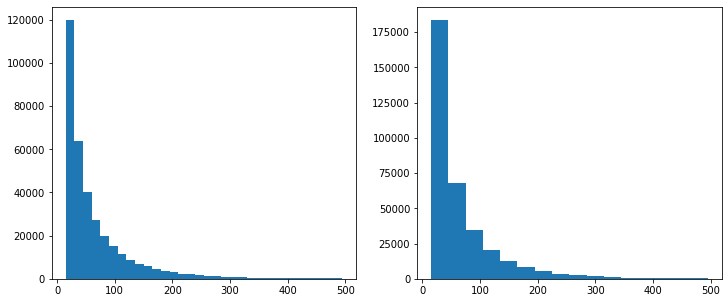

```python
#create bins of 15 minutes and 30 minutes each to see the plot side by side
plt.figure(figsize = [12,5])

#subplot1
plt.subplot(1,2,1)
bin_edges = np.arange(15, 500, 15)
plt.hist(data = flt_data[flt_data['on_time'] == "delayed"], x = "dep_delay_time", bins = bin_edges)

#subplot1
plt.subplot(1,2,2)
bin_edges = np.arange(15, 500, 30)
plt.hist(data = flt_data[flt_data['on_time'] == "delayed"], x = "dep_delay_time", bins = bin_edges)
```

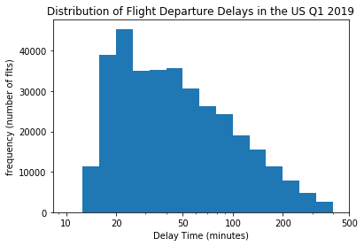

```python
# We'll need to perform scale transformation to the plot above to better detect any patterns in distribution.

bin_edges = 10**np.arange(1, np.log10(500),0.1 )
plt.hist(data = flt_data[flt_data['on_time'] == "delayed"], x = "dep_delay_time", bins = bin_edges)
plt.xscale("log")
tick_locs = [10,20,50,100,200,500]
plt.xticks(tick_locs,tick_locs)
plt.xlabel("Delay Time (minutes)")
plt.ylabel("frequency (number of flts)")
plt.title("Distribution of Flight Departure Delays in the US Q1 2019")
```

A: From the histogram above, we can see that in the first quarter of 2019, the distribution of flights originating in the US by delay time is unimodal and right-skewed. The most common delay time at departure is around 25 minutes. Number of delayed flights gradually decreases after 50 minutes mark. It's very rare for flights to have been delayed for more than 200 minutes.

### 3.1.2 Delay by Category

```python
#first melt variables related to delay cause to two variables "delay_cause" and "delay_time"
delay_subset = pd.melt(flt_data[flt_data['on_time'] == "delayed"],\
                       id_vars = ['crsdep_timestamp', "mkt_carrier", 'origin', 'dest', 'date', 'hour', 'weekday'], \
                       value_vars=['weather_delay', 'carrier_delay','nas_delay','security_delay', 'late_aircraft_delay' ],\
                       var_name='delay_cause', value_name='delay_time')
```

```python
delay_subset.to_csv('delay_subset.csv')
```

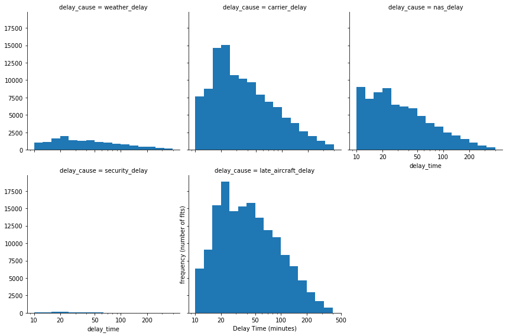

```python
#Create a facetgrid to compare different causes.

#set grid
g = sb.FacetGrid(data = delay_subset, col = "delay_cause", height = 4,  col_wrap=3)

#plot
bin_edges = 10**np.arange(1, np.log10(500),0.1 )
g.map(plt.hist, "delay_time", bins = bin_edges)

#set x scale transformation
plt.xscale("log")
tick_locs = [10,20,50,100,200,500]
plt.xticks(tick_locs,tick_locs)
plt.xlabel("Delay Time (minutes)")
plt.ylabel("frequency (number of flts)")
```

### 3.1.3 Flight Cancellation by Category

```python
#replace code with strings to create better visualisation
flt_data.replace({'cancellation_code': {"A": "carrier", "B": "weather", "C": "nas", "D":"security"}}, inplace = True)
```

```python
#subset data to include observations with a cancellation code
cancel_subset = flt_data[pd.notnull(flt_data['cancellation_code'])]
```

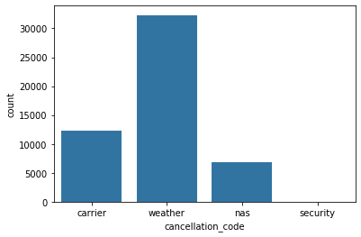

```python
base_color = sb.color_palette()[0]
sb.countplot(data = cancel_subset, x = "cancellation_code",color = base_color )
```

We can see weather is the number one reason for flight cancellations, followed by carrier-related reasons and air traffic control. Security, on the other hand, only caused a negligible amount of flight cancellations.

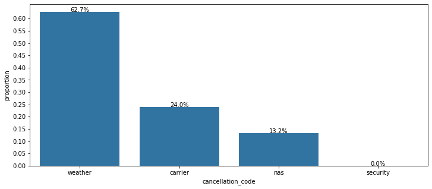

```python
# we can see the relative frequency of flight cancellations.


#calculate the largest percentage among all categories and set it as bourndary of the y-axis
n_points = cancel_subset.shape[0]
max_count = cancel_subset['cancellation_code'].value_counts().max()
max_prop = max_count / n_points

#Create y-axis ticks
tick_props = np.arange(0, max_prop, 0.05)
tick_names = ['{:0.2f}'.format(i) for i in tick_props]


#calculate the count of each category and put it in a variabel
code_count = cancel_subset['cancellation_code'].value_counts()

#set plot size
plt.figure(figsize = [12,5])

#create plot and put portions in order from largest to smallest
sb.countplot(data = cancel_subset, x = 'cancellation_code', color = base_color, order = code_count.index)
plt.yticks(tick_props*n_points, tick_names)
plt.ylabel('proportion')

#add annotation to each bar.
locs, labels = plt.xticks()
for loc,label in zip(locs,labels):
    count = code_count[label.get_text()]
    pct_string = '{:0.1f}%'.format(100*count/n_points)
    plt.text(loc,count-8,pct_string,ha="center",color="black")
```

we can see from the plot above that weather caused 62.7% of flight cancellations

### 3.2 Bivariate Data Visualization

```python
def reformat_large_tick_values(tick_val, pos):
    if tick_val >= 1000:
        val = round(tick_val/1000, 0)
        new_tick_format = '{:,.0f}K'.format(val)
        # make new_tick_format into a string value
        tick_format = str(new_tick_format)
    else:
        tick_format = str(tick_val)
    return tick_format
```

### 3.2.1 Comparison between Number of On-time Flights and Number of Delayed Flights

[output not shown]

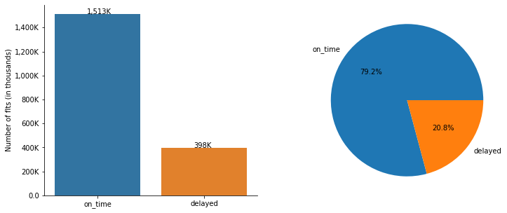

```python
#subplot
plt.figure(figsize = [12,5])


data = flt_data["on_time"].value_counts()
labels = data.index

#subplot1
plt.subplot(1,2,1)
ax = sb.countplot(data = flt_data, x = "on_time")
for i, v in data.reset_index().iterrows():
    ax.text(i-0.1, v.on_time + 0.2 , '{:,.0f}K'.format(v.on_time/1000), color='black')
import matplotlib as mpl
ax.yaxis.set_major_formatter(mpl.ticker.FuncFormatter(reformat_large_tick_values))
plt.xlabel("")
plt.ylabel("Number of flts (in thousands)")





# get rid of the frame
plt.gca().spines['top'].set_visible(False)
plt.gca().spines['right'].set_visible(False)

#subplot 2
plt.subplot(1,2,2)
data = flt_data["on_time"].value_counts()
labels = data.index
plt.pie(data,labels = labels, autopct = '%1.1f%%')
```

Delayed flights represent 20% of total domestic flights, which means 80% of the flights are on-time.

### 3.2.2 Average Departure Delay by Hour of the Day

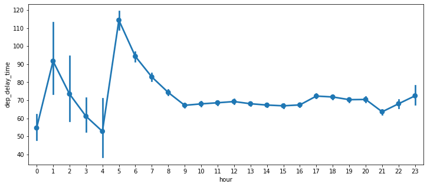

```python
#Create a pointplot describing the mean of dep delay time by hour of the day.
plt.figure(figsize = [12,5])
sb.pointplot(data = flt_data[flt_data['on_time'] == "delayed"] ,x = 'hour', y = "dep_delay_time")
```

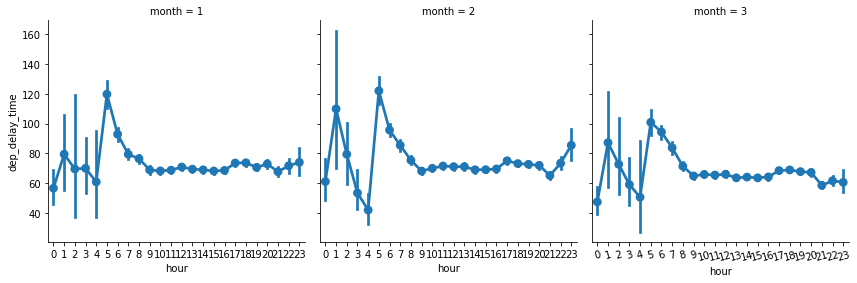

```python
#set grid
g = sb.FacetGrid(data = flt_data[flt_data['on_time'] == "delayed"], col = 'month',\
                 height = 4,  col_wrap=3, margin_titles = True)

#plot
g.map(sb.pointplot, 'hour', "dep_delay_time")
plt.xticks(rotation = 15)
```

The variation from month to month doesn't seem to be very significant although March does see a drop in delay times.

### 3.2.3 Average Departure Delay by Day of the Week

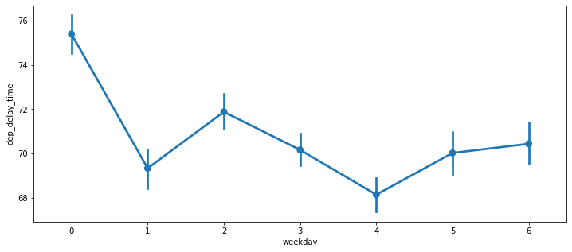

```python
#create pointplot by extracting weekday from the scheduled departure datetime object
plt.figure(figsize = [12,5])
sb.pointplot(data = flt_data[flt_data['on_time'] == "delayed"] ,x = 'weekday', y = 'dep_delay_time')
```

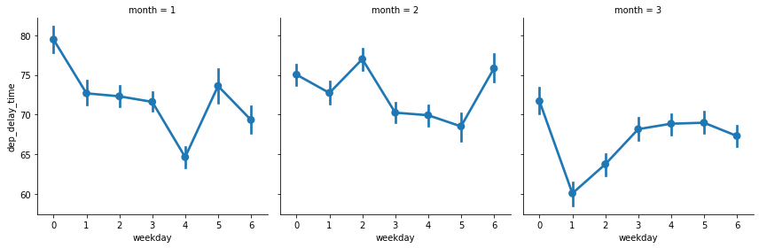

```python
#set grid
g = sb.FacetGrid(data = flt_data[flt_data['on_time'] == "delayed"], col = 'month', height = 4,margin_titles = True)

#plot
g.map(sb.pointplot, 'weekday', "dep_delay_time")
```

Monday flights suffer the longest average delay. Although in Feb, Wed has the longest delay time.

### 3.2.4 Average Delay Time by Category

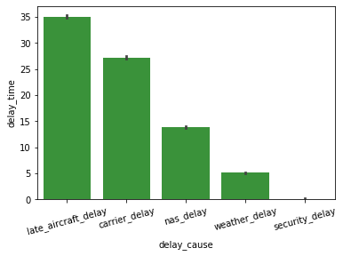

```python
#create summary dataframe about delayed flights by hours of the day.
base_color = sb.color_palette()[2]

order = delay_subset.groupby('delay_cause')['delay_time'].mean().reset_index().\
           sort_values(by = 'delay_time',ascending = False)['delay_cause']

sb.barplot(data = delay_subset, x = 'delay_cause', y = "delay_time",order = order,color = base_color)
plt.xticks(rotation = 15)
```

The average delay time by late aircraft arrival is 35 minutes, compared with 27 minutes by carrier_related issues, 14 minutes by National Air System caused problems and only 5 minutes by weather.

### 3.2.5 Number of delayed flights by Airports

```python
#group data and put it into dataframe
airport_delay = flt_data[flt_data['on_time'] == "delayed"].groupby(['origin'])['dep_delay_time'].count()

airport_delay = airport_delay.reset_index().rename(columns= {'dep_delay_time': 'total_delayed_flts'}).\
                         sort_values('total_delayed_flts',ascending=False)
```

```python
#select top 20 airports with largest number of delayed flights.

top20_delay_airports = airport_delay.head(20)
```

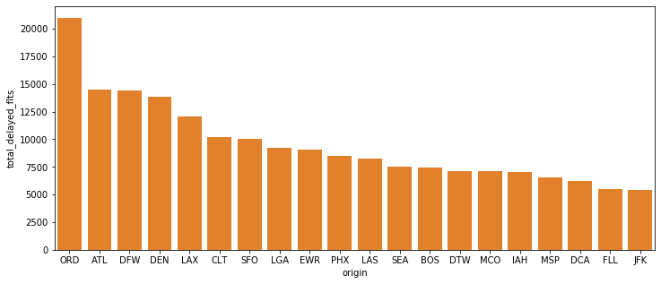

```python
#create plot
plt.figure(figsize = [12,5])

base_color = sb.color_palette()[1]

sb.barplot(data = top20_delay_airports, x = 'origin', y = "total_delayed_flts", color = base_color)
```

### 3.3 Multivariate Data Visualization

```python
#import airport category file
airport_category = pd.read_csv('airport_category.csv', usecols=["IATA", "Role"])
```

```python
#rename column
airport_category.rename(columns = {'Role': "size_category"}, inplace = True)
```

```python
airport_category['size_category'].unique()
```

```
array([nan, 'P-S', 'P-N', 'P-M', 'P-L', 'P-N\xa0[nb 1]'], dtype=object)
```

```python
#replace values in the size_category variable to make them more understandable
airport_category.replace({'size_category': {"P-S": "small", "P-N": "non_hubI", "P-M": "medium", "P-L":"large",\
                                           'P-N\xa0[nb 1]': 'non_hubII'}}, inplace = True)
```

```python
#turn size_category to ordered categorical data type
order = ['large', 'medium', 'small','non_hubI','non_hubII']
ordered_category = pd.api.types.CategoricalDtype(ordered = True, categories = order)
airport_category['size_category'] = airport_category['size_category'].astype(ordered_category)
```

### 3.3.1 On-time Departure Rate and Size of Airport

```python
#create the denominator (total number of departures) and store it in a dataframe

denominator = flt_data.groupby(['origin'])['origin'].count().reset_index(name = "total_flts")
```

```python
#store the number of on-time departures in a dataframe
numerator = flt_data[flt_data['on_time'] == "on_time"].groupby(['origin'])['origin'].count().reset_index(name = "on_time_flts")
```

```python
#merge the two dataframe
airport_subset = denominator.merge(numerator, how = "left", on = ["origin"]).merge(airport_category, how = 'left',\
                                                                           left_on = "origin", right_on = "IATA")
```

```python
#calculate on-time departure rate
airport_subset['on_time_rate'] = airport_subset['on_time_flts'] / airport_subset['total_flts']
```

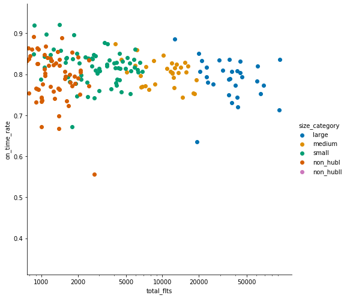

```python
g = sb.FacetGrid(data = airport_subset, hue = 'size_category',height = 7,palette = 'colorblind')
g.map(plt.scatter,  "total_flts",  "on_time_rate")
plt.xscale('log')
tick_locs = [1000,2000,5000,10000,20000,50000]
plt.xticks(tick_locs,tick_locs)
g.add_legend()
```

Airport size doesn't seem to have any influence on on-time departure rate.

### 3.3.2 On-time Performance Top/Bottom 5 Airports by Size Category

I'm curious about top/bottom airports in each size category.

```python
#exclude non-hub category
category_subset = airport_subset.copy()
category_subset['size_category'] = category_subset.size_category.cat.remove_categories(['non_hubI', 'non_hubII'])
category_subset.dropna(subset = ['size_category'], inplace = True)
```

```python
category_subset.to_csv('category_subset.csv')
```

```python
#select top 5
top_5 = category_subset.sort_values('on_time_rate',ascending = False).\
                                  groupby('size_category').head(5)
```

```python
#select bottom 5
bottom_5 = category_subset.sort_values('on_time_rate',ascending = False).groupby('size_category').tail(5)
```

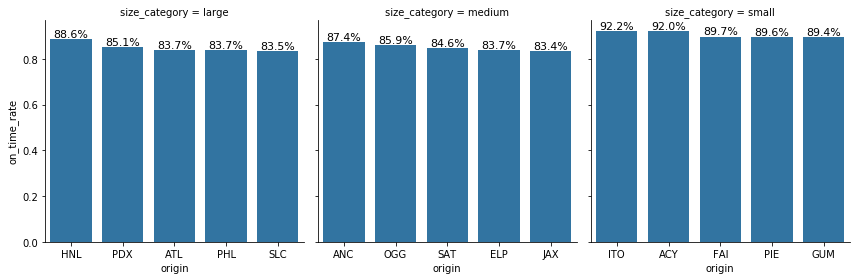

```python
#also curious about the top/bottom airports in terms of on-time performance in each category.
#set grid
g = sb.FacetGrid(data = top_5, col = 'size_category', height = 4,sharex= False)

g.map(sb.barplot, "origin", 'on_time_rate')

for ax in g.axes.flat:
    for p in ax.patches:
             ax.annotate('{:,.1%}'.format(p.get_height()), (p.get_x() + p.get_width() / 2., p.get_height()),
                 ha='center', va='center', fontsize=11, color='black', xytext=(0, 5),
                 textcoords='offset points')


for idx, v in enumerate(top_5.size_category.cat.categories):
    g.axes.flat[idx].set_xticklabels(top_5[top_5.size_category == v]['origin'])
```

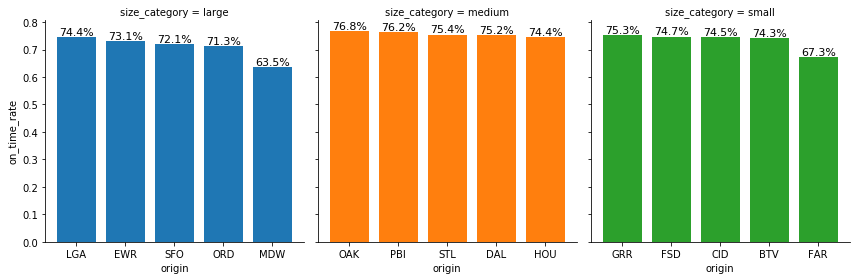

```python
g = sb.FacetGrid(data = bottom_5, col = 'size_category', height = 4,sharex= False, hue = 'size_category')
g.map(plt.bar, "origin", 'on_time_rate')

for ax in g.axes.flat:
    for p in ax.patches:
             ax.annotate('{:,.1%}'.format(p.get_height()), (p.get_x() + p.get_width() / 2., p.get_height()),
                 ha='center', va='center', fontsize=11, color='black', xytext=(0, 5),
                 textcoords='offset points')


for idx, v in enumerate(bottom_5.size_category.cat.categories):
    g.axes.flat[idx].set_xticklabels(bottom_5[bottom_5.size_category == v]['origin'])
```

Chicago O'Hare saw the highest number of delayed flights among all airports in the US, followed by Atlanta and Dallas Fortworth. The most punctual large airport in the US is Honolulu. In the medium and small size categories, winners are Anchorage and Hilorespectively. All of the three airports are not attached to the 48 states in North America. Two least punctual large airports serve New York while the other two serve Chicago. The remaining one is SFO.

### 3.3.2 On-time Performance by Carrier

```python
#create the denominator (total number of departures) and store it in a dataframe
denominator_carrier = flt_data.groupby(['mkt_carrier'])['mkt_carrier'].count().reset_index(name="total_flts")

numerator_carrier = flt_data[flt_data['on_time'] == "on_time" ].groupby(['mkt_carrier'])['mkt_carrier'].count().reset_index(name = "on_time_flts")
```

```python
ontime_carrier = denominator_carrier.merge(numerator_carrier, how = "left", on = "mkt_carrier")
ontime_carrier['on_time_rate'] = ontime_carrier['on_time_flts'] / ontime_carrier['total_flts']
```

```python
ontime_carrier.to_csv('ontime_carrier.csv')
```

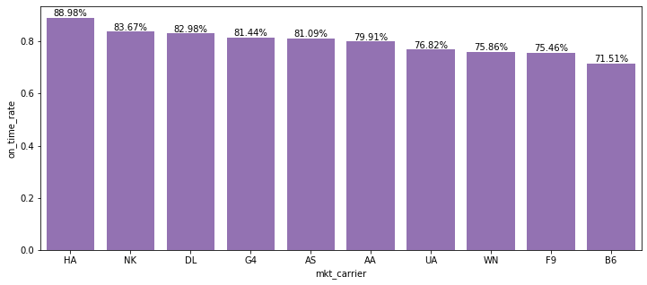

```python
plt.figure(figsize = [12,5])


base_color = sb.color_palette()[4]

ax = sb.barplot(data = ontime_carrier, x = ontime_carrier.sort_values(by ="on_time_rate", ascending = False)['mkt_carrier'],\
                y = "on_time_rate", color = base_color)



for i, v in enumerate(ontime_carrier.sort_values(by ="on_time_rate", ascending = False)['on_time_rate'].iteritems()):
    ax.text(i ,v[1], "{:.2%}".format(v[1]), color='black', va ='bottom', ha = 'center')

plt.show()
```

Hawaiian Airlines, Spirit and Delta Air Lines are the top three on-time carriers in the US.

### 3.3.3 Legacy Carriers On-time Departure Performance by Hub

United, Delta and American, the so called "big-three" US legacy carriers, evolved from bankruptcy years and have invested heavily in their respective hubs. I want to investigate their hub on-time performance.

```python
# first, we'll create a dictionary with carrier name as key and store the hubs into lists inside the dictionary.
dict_of_hubs = {}

dict_of_hubs['DL'] = ['ATL', 'MSP','SEA', 'JFK','DTW','BOS','SLC']
dict_of_hubs['AA'] = ['DFW', 'DCA','PHL','LAX','MIA','CLT','ORD','JFK']
dict_of_hubs['UA'] = ['ORD','DEN','IAH','SFO','IAD','EWR']
```

```python
# then we can select observations with the carrier+hub combination
carrier_airport_total = flt_data.groupby(['mkt_carrier', 'origin'])['origin'].count()

hub_total = carrier_airport_total.loc[[(k,v) for k in dict_of_hubs.keys() for v in dict_of_hubs[k]]].\
             reset_index(name = "total_flts")
```

```python
#we'll do the same with on-time flights
carrier_airport_ontime = flt_data[flt_data['on_time']=="on_time"].groupby(['mkt_carrier', 'origin'])\
                                           ['origin'].count()

hub_ontime = carrier_airport_ontime.loc[[(k,v) for k in dict_of_hubs.keys() for v in dict_of_hubs[k]]].\
             reset_index(name = "ontime_flts")
```

```python
#merge the two dataframes
hub_performance = hub_total.merge(hub_ontime, how = "left", on = ['mkt_carrier', 'origin'])
hub_performance['on_time_rate'] = hub_performance['ontime_flts'] / hub_performance['total_flts']
```

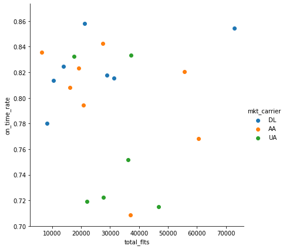

```python
g= sb.FacetGrid(data = hub_performance, hue = 'mkt_carrier', height = 6)
g.map(plt.scatter,"total_flts",  "on_time_rate")
g.add_legend()
```

United Airlines hubs seems to fall behind Delta and most of the American Airlines hubs. Delta has the best performing hubs in terms of on-time departures.